# **Lab6 - Data Visualization**

## Histograms

Histograms need a set of numbers that will be categorized into bins. In a way, the bins are like "categories" and the resulting chart looks like a column chart, except that $x$-axis is a continuous variable that is just "segmented", and the $y$-axis is the frequency of numbers appearing in that bin.

### Simple example

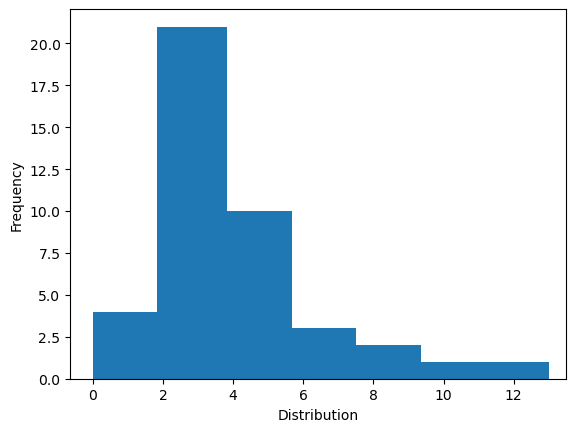

```python
x=[0,1,2,2,3,3,3,3,3,3,4,4,4,4,4,4,4,4,4,4,4,4,4,4,4,5,5,5,5,5,6,6,6,6,6,7,7,8,9,10,11,15]

userbin=7 #try using userbin=[0,2,4,6,8,10,12,14]
counts, bins = np.histogram(x,bins=userbin)
plt.hist(bins[:-1],bins=userbin,weights=counts, width=2)

plt.ylabel('Frequency')
plt.xlabel('Distribution')
plt.show()
```

Pandas also has a built-in histogram command.

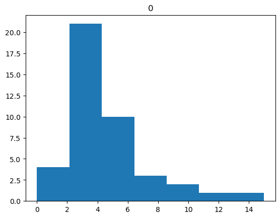

```python
dfsimple=pd.DataFrame(x)
dfsimple.hist(bins=7,grid=False)
plt.show()
```

Note that as in any graph, it is possible to customize our histograms, but that is left for the student to explore.

### Real data

Let us again use the data from FIFA women's.

1. Create a histogram for the overall column.
2. Create a histogram for each of the columns on overall, potential, weight, and height.

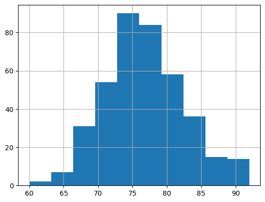

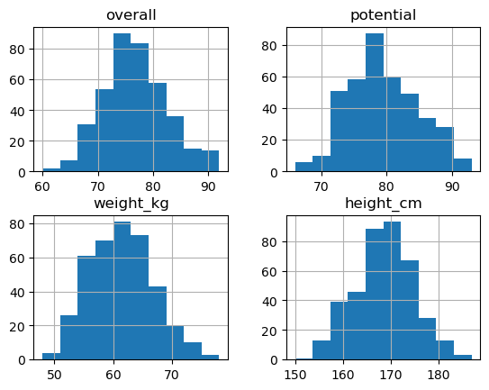

```python
df['overall'].hist()
df[['overall','potential','weight_kg','height_cm']].hist()

plt.show()
```

Your turn! Create a histogram for the age of the players. Try using both methods used above (using matplotlib and using the built-in pandas function).

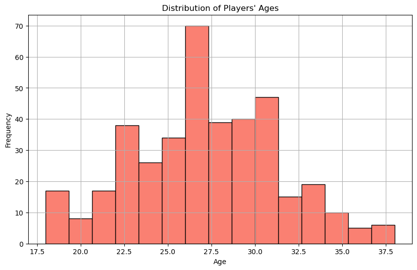

```python
# type your code here
import matplotlib.pyplot as plt
df['age'].hist(bins=15, figsize=(10, 6), color='salmon', edgecolor='black')
plt.title('Distribution of Players\' Ages')
plt.xlabel('Age')
plt.ylabel('Frequency')
plt.show()
```

## Boxplots

Bocplots use the same information as histograms, and somehow shows how the numerical data is distributed. While histograms have an edge indetermining the shape, normality, and skewness, boxplots have an additional function of comparison between groups.

### Simple example

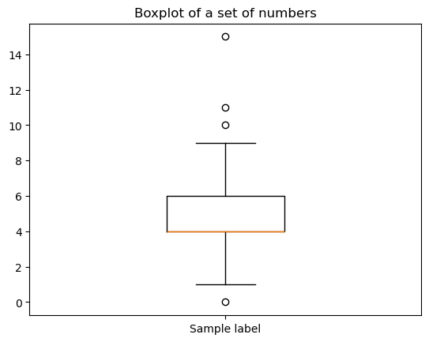

```python
x=[0,1,2,2,3,3,3,3,3,3,4,4,4,4,4,4,4,4,4,4,4,4,4,4,4,5,5,5,5,5,6,6,6,6,6,7,7,8,9,10,11,15]

labels=['Sample label']
plt.boxplot(x,
            labels=labels,
            widths=(0.3),
            vert=True,
            whis=1.5)

plt.title('Boxplot of a set of numbers')
plt.show()
```

### Real data

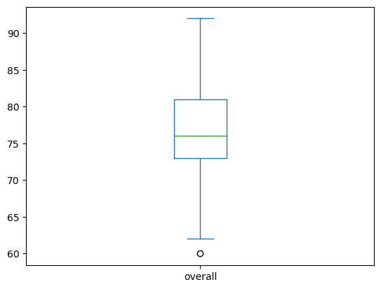

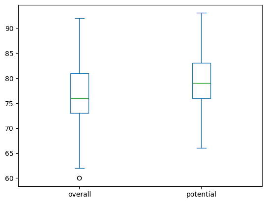

```python
df['overall'].plot.box()

df[['overall','potential']].plot.box()

plt.show()
```

Your turn! Give the boxplots that compare the following skills of the players: pace, shooting, passing, dribbling, defending, physic. Hint: These are the actual column names.

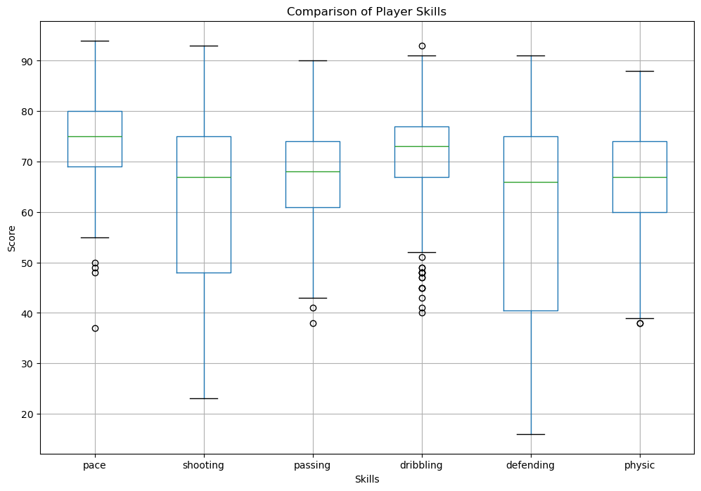

```python
# type your code here
import matplotlib.pyplot as plt
skills = ['pace', 'shooting', 'passing', 'dribbling', 'defending', 'physic']
plt.figure(figsize=(12, 8))
df[skills].boxplot()
plt.title('Comparison of Player Skills')
plt.xlabel('Skills')
plt.ylabel('Score')
plt.show()
```

### Challenge (Optional)

Can we make a histogram/boxplot of players' overall rating for each team? Yes.

Option 1: Use pivot_table to make a table, and then convert this table to a pandas dataframe, and then plot.

Option 2: Use a loop to make a plot of a filtered dataframe, then plot.

[figure not shown]

```python
import pandas as pd
import seaborn as sns
import matplotlib.pyplot as plt
df_cleaned = df.dropna(subset=['club_name', 'overall'])
plt.figure(figsize=(12, 8))
sns.boxplot(x='club_name', y='overall', data=df_cleaned)

# Rotate x-axis labels for better readability
plt.xticks(rotation=90)
plt.title("Boxplot of Players' Overall Rating by Team")
plt.xlabel("Team")
plt.ylabel("Overall Rating")
plt.show()
```

[figure not shown]

```python
import matplotlib.pyplot as plt

teams = df['club_name'].unique()
team_data = [df[df['club_name'] == team]['overall'] for team in teams]

plt.figure(figsize=(12, 8))
plt.boxplot(team_data, labels=teams, vert=True)
plt.xticks(rotation=90)
plt.title("Boxplot of Players' Overall Rating by Team")
plt.xlabel("Team")
plt.ylabel("Overall Rating")
plt.show()
```

As you saw in the histogram and boxplot, pandas actually has built-in plotting capabilities (based on matplotlib). You can see more information from https://pandas.pydata.org/docs/reference/api/pandas.DataFrame.hist.html.

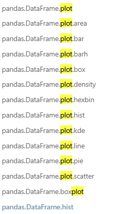

## Congratulations

You have finished this module.

## Acknowledgement, Ownership, and References

This notebook is prepared by Emmanuel Plan (emmanuelplan@hsb.edu.vn) for HSB3119: Introduction to Data Science.

## References

1. Jupyter Notebook of HSB1003 Data Analysis for MAS2, Emmanuel Plan, 2022-2023 Semester 1.
2. Leone, S. FIFA 22 complete player dataset. Accessed on 21 Aug 2023. Link:"https://www.kaggle.com/datasets/stefanoleone992/fifa-22-complete-player-dataset?resource=download".
3. Google Trends data of Vietnam, 2020-2022.

### Changelog

1. 2023-08-24: Drafted initial version